# Devoir 2

*Thibaud Ritzenthaler*

*Disponible sur ce [thibaud-ritzenthaler.github.io/M1demo-AD-devoir2](https://thibaud-ritzenthaler.github.io/M1demo-AD-devoir2/), le code source sur [Github](https://github.com/thibaud-ritzenthaler/M1demo-AD-devoir2)*.

# Exercice 1

## Introduction

**Note : dans cet exercice, on parlera de fécondité naturelle pour parler de la fécondité des femmes non mariées**

Voir les figures de cet exercice (1, 2, 3) en Annexe.

## Partie 1

### Démarches de construction des tables et graphiques

On doit poser ici l’hypothèse de continuité et d’indépendance des naissances, des mariages ainsi que des mariages et des naissances entre eux.

Pour calculer les taux de fécondité générale par âge $f_{x}$, on divise pour chaque âge le nombre de naissances à l’âge $x$, noté $N_{(x,x+1)}$, par la population des femmes à l’âge $x$, noté $P_{(x+0,5)}$. On a $f_{x} = \frac{N_{(x,x+1)}}{P_{(x+0,5)}}$. Comme on a uniquement les valeurs pour 5 ans, on applique les valeurs pour les 5 ans : $f_{x+5} = \frac{N_{(x,x+5)}}{P_{(x+2,5)}}$

Pour calculer les taux de fécondités totaux, on fait la somme des taux aux différentes cohortes d’age : $\sum_{x=15}^{49} f_{x}$

Il faut poser l’hypothèse d’indépendance des phénomènes de naissance légitime par âge $x$, noté $fl_{x}$, et de naissance naturelle par âge $x$, noté $fn_{x}$.

Pour rapporter le nombre de naissances légitimes au nombre de mariages, on a par âge $x$ : $\frac{Nl_{x,x+5}}{M_{(x+2,5)}}$

Le calcul du total des années vécues au sein du mariage est le suivant : $\sum_{x=15}^{49} Maries_{x + 0,5}$. Comme nous n’avons pas le détail par an, mais par 5 ans, on prend les mariées à l’age $x + 2,5$

### Commentaire

## Partie 2

### Démarches de construction des tables et graphiques

Les démarches sont sensiblement les mêmes que dans la partie 1, avec les nouvelles données.

### Commentaire

## Conclusion

# Exercice 2

Voir les figures de cet exercice en Annexe.

### Démarches de construction des tables et graphiques

Afin de construire les graphiques, onn doit poser les hypothèses d’indépendance et de continuité des phénomènes au sein des différentes classes d’âges.

### Commentaires

# Exercice 3

Voir les figures de cet exercice en Annexe.

### Démarches de construction des tables et graphiques

Le nombre moyen d’enfants par famille se calcule en multipliant le nombre d’enfants par famille $N_{e}$ par le nombre de familles relatif $N_{f}$ en ratio puis en additionnant les résultats : $\sum N_{e}\cdot\frac{N_{f}}{100}$

Le taux de mortalité infantile de l’ensemble des enfants correspond à la moyenne des taux de mortalité pondérés par les ratios des familles affectées par ce taux de mortalité infantile.

Le taux de mortalité infantile de chaque rang de naissance pour l’ensemble des familles ayant des enfants de ce rang se calcule en faisant le ratio de la mortalité infantile $M_{f,\cdots, f+n}$ par le nombre relatif de familles de la dimension avec 100 familles $N_{f,\cdots, f+n}$ par le pourcentage des familles ayant connu le phénomène (par exemple toutes les familles ayant 4 enfants ont connu le phénomène de mortalité infantile à 1, 2 et 3 enfants) $P_{f}$.

### Commentaires

# Annexes

### Figures exercice 1

|  | Mariages | Naissances | Naissances légitimes | Taux de fécondité $f_{(x,x+5)}$ | Taux de fécondité légitime $fl_{(x,x+5)}$ | Taux de fécondité naturel $fn_{(x,x+5)}$ |
| --- | --- | --- | --- | --- | --- | --- |
| [15-19[ | 50 | 157 | 11 | 0.031 | 0.003 | 0.112 |
| [20-24[ | 200 | 883 | 246 | 0.177 | 0.066 | 0.490 |
| [25-29[ | 300 | 1664 | 824 | 0.333 | 0.223 | 0.646 |
| [30-34[ | 100 | 1027 | 547 | 0.205 | 0.148 | 0.369 |
| [35-39[ | 50 | 457 | 262 | 0.091 | 0.071 | 0.150 |
| [40-44[ | 25 | 143 | 85 | 0.029 | 0.023 | 0.045 |
| [45-49[ | 10 | 69 | 42 | 0.014 | 0.011 | 0.021 |
| Total | 735 | 4400 | 2017 | 0.880 | 0.545 | 1.833 |

|  | Composantes légitime | Composante naturelle | Naissances légitimes par mariage | Années vécues |
| --- | --- | --- | --- | --- |
| [15-19[ | 0.002 | 0.029 | 0.220 | 250 |
| [20-24[ | 0.049 | 0.127 | 1.230 | 1250 |
| [25-29[ | 0.165 | 0.168 | 2.747 | 2750 |
| [30-34[ | 0.109 | 0.096 | 5.470 | 3250 |
| [35-39[ | 0.052 | 0.039 | 5.240 | 3500 |
| [40-44[ | 0.017 | 0.012 | 3.400 | 3625 |
| [45-49[ | 0.008 | 0.005 | 4.200 | 3675 |
| Total | 0.402 | 0.476 | 2.744 | 3675 |

| Nombre moyen de naissances légitimes par année de mariage |
| --- |
| 0.404 |

*Figure 1 : Table de nuptialité et de fécondité, naturelle, légitime et totale issue de la partie 1*

|  | Mariages | Naissances | Naissances légitimes | Taux de fécondité $f_{(x,x+5)}$ | Taux de fécondité légitime $fl_{(x,x+5)}$ | Taux de fécondité naturel $fn_{(x,x+5)}$ |
| --- | --- | --- | --- | --- | --- | --- |
| [15-19[ | 50 | 150 | 4 | 0.03 | 0.001 | 0.112 |
| [20-24[ | 200 | 750 | 113 | 0.15 | 0.031 | 0.490 |
| [25-29[ | 300 | 1400 | 560 | 0.28 | 0.151 | 0.646 |
| [30-34[ | 100 | 1200 | 720 | 0.24 | 0.195 | 0.369 |
| [35-39[ | 50 | 600 | 405 | 0.12 | 0.109 | 0.150 |
| [40-44[ | 25 | 200 | 142 | 0.04 | 0.038 | 0.045 |
| [45-49[ | 10 | 100 | 73 | 0.02 | 0.020 | 0.021 |
| Total | 735 | 4400 | 2017 | 0.88 | 0.545 | 1.833 |

|  | Composantes légitime | Composante naturelle | Naissances légitimes par mariage | Années vécues |
| --- | --- | --- | --- | --- |
| [15-19[ | 0.001 | 0.029 | 0.080 | 250 |
| [20-24[ | 0.023 | 0.127 | 0.565 | 1250 |
| [25-29[ | 0.112 | 0.168 | 1.867 | 2750 |
| [30-34[ | 0.144 | 0.096 | 7.200 | 3250 |
| [35-39[ | 0.081 | 0.039 | 8.100 | 3500 |
| [40-44[ | 0.028 | 0.012 | 5.680 | 3625 |
| [45-49[ | 0.015 | 0.005 | 7.300 | 3675 |
| Total | 0.404 | 0.476 | 2.744 | 3675 |

| Nombre moyen de naissances légitimes par année de mariage |
| --- |
| 0.596 |

*Figure 2 : Table de nuptialité et de fécondité, naturelle, légitime et totale issue de la partie 2*

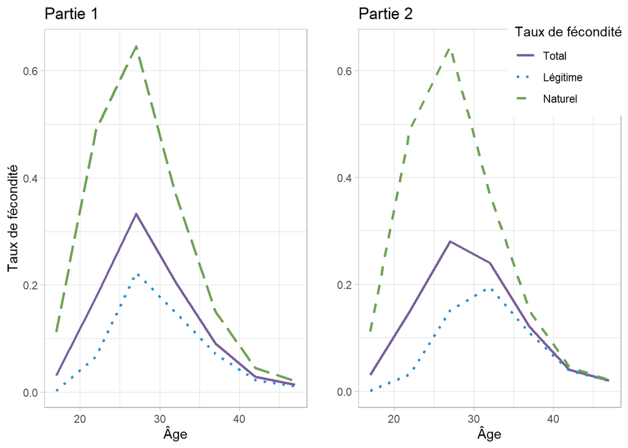

*Figure 3 : Evolution des taux de fécondité des femmes en général, des femmes mariées et des femmes non mariées en fonction de leur âge*

### Figures exercice 2

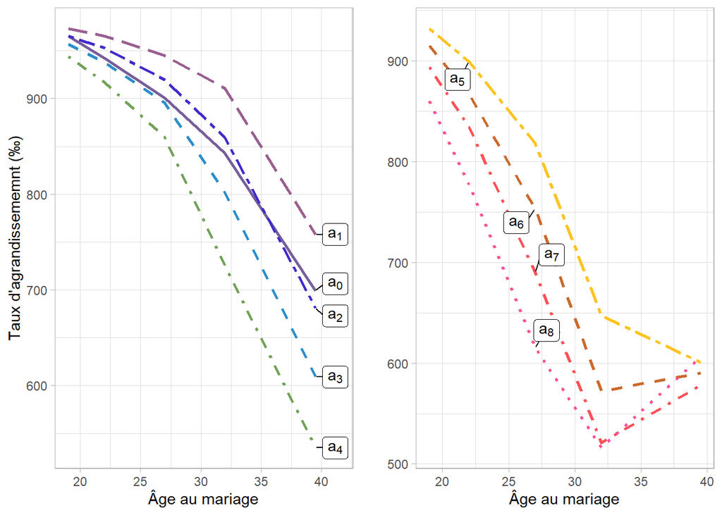

*Figure 4 : Probabilité d’agrandissement en fonction de l’âge au mariage des femmes*

```r
# For interpolation
Interp <- data.frame(
         Age  = c(20, 25, 30, 35),
         a0 = round(approx(as.numeric(AgeMariageFemmePivot1[AgeMariageFemmePivot1$aggr == "a0",]$age),
                           AgeMariageFemmePivot1[AgeMariageFemmePivot1$aggr == "a0",]$proba,
                           xout = c(20, 25, 30, 35))$y),
         a1 = round(approx(as.numeric(AgeMariageFemmePivot1[AgeMariageFemmePivot1$aggr == "a1",]$age),
                     AgeMariageFemmePivot1[AgeMariageFemmePivot1$aggr == "a1",]$proba,
                     xout = c(20, 25, 30, 35))$y),
         a2 = round(approx(as.numeric(AgeMariageFemmePivot1[AgeMariageFemmePivot1$aggr == "a2",]$age),
                     AgeMariageFemmePivot1[AgeMariageFemmePivot1$aggr == "a2",]$proba,
                     xout = c(20, 25, 30, 35))$y),
         a3 = round(approx(as.numeric(AgeMariageFemmePivot1[AgeMariageFemmePivot1$aggr == "a3",]$age),
                     AgeMariageFemmePivot1[AgeMariageFemmePivot1$aggr == "a3",]$proba,
                     xout = c(20, 25, 30, 35))$y),
         a4 = round(approx(as.numeric(AgeMariageFemmePivot1[AgeMariageFemmePivot1$aggr == "a4",]$age),
                     AgeMariageFemmePivot1[AgeMariageFemmePivot1$aggr == "a4",]$proba,
                     xout = c(20, 25, 30, 35))$y)
)
```

| Age | a0 | a1 | a2 | a3 | a4 |
| --- | --- | --- | --- | --- | --- |
| 20 | 957 | 970 | 961 | 951 | 935 |
| 25 | 917 | 953 | 933 | 913 | 883 |
| 30 | 866 | 925 | 883 | 840 | 780 |
| 35 | 785 | 850 | 788 | 725 | 650 |

*Figure 5 : Interpolations calculées entre les âges*

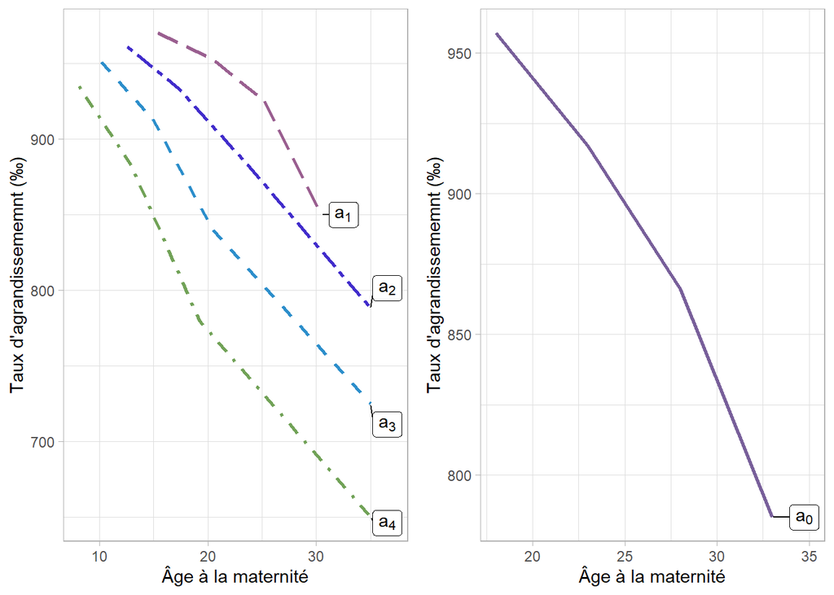

*Figure 6 : Valeurs interpolées en correspondance avec l’âge de la mère à la naissance du $n^{ième}$ enfant*

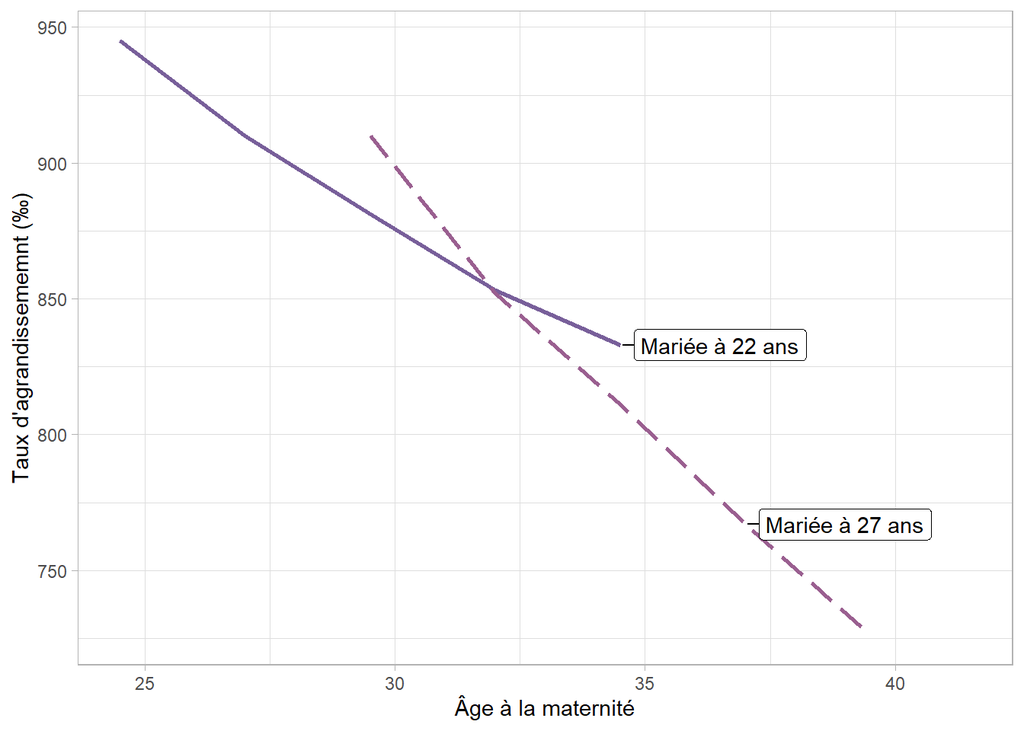

*Figure 7 : Probabilité d’agrandissement en fonction de l’âge à la maternité des femmes, par rang de l’enfant et âge au mariage.*

### Figures exercice 3

| Nombre moyen d’enfants par famille |
| --- |
| 2.75 |

| Taux de mortalité infantile de l’ensemble des enfants |
| --- |
| 115 |

| Nombre d’enfant.s | Nombre de familles | Taux de mortalité infantile (‰) | taux de mortalité infantile de chaque rang de naissance (‰) |
| --- | --- | --- | --- |
| 1 | 25 | 80 | 115 |
| 2 | 25 | 100 | 127 |
| 3 | 20 | 120 | 140 |
| 4 | 15 | 140 | 153 |
| 5 | 10 | 160 | 167 |
| 6 | 5 | 180 | 180 |

*Figure 8 : Tableaux des indicateurs des familles et des mortalités.*